# The Composition of the American Electorate, 1980–2024

UT Austin Political Methodology Seminar

Devin Caughey

MIT

Bernard Fraga

Emory

Chris Warshaw

Georgetown

Rob Griffin

Democracy Fund

October 23, 2025

# Motivation

## The importance of measuring turnout

### Why does voter turnout matter?

- Turnout (esp. when low) is often seen as an indicator of democratic vitality.
- By this metric, American democracy is healthier than it has been in a century!
- Sarcasm aside, aggregate turnout is not the only thing that matters.

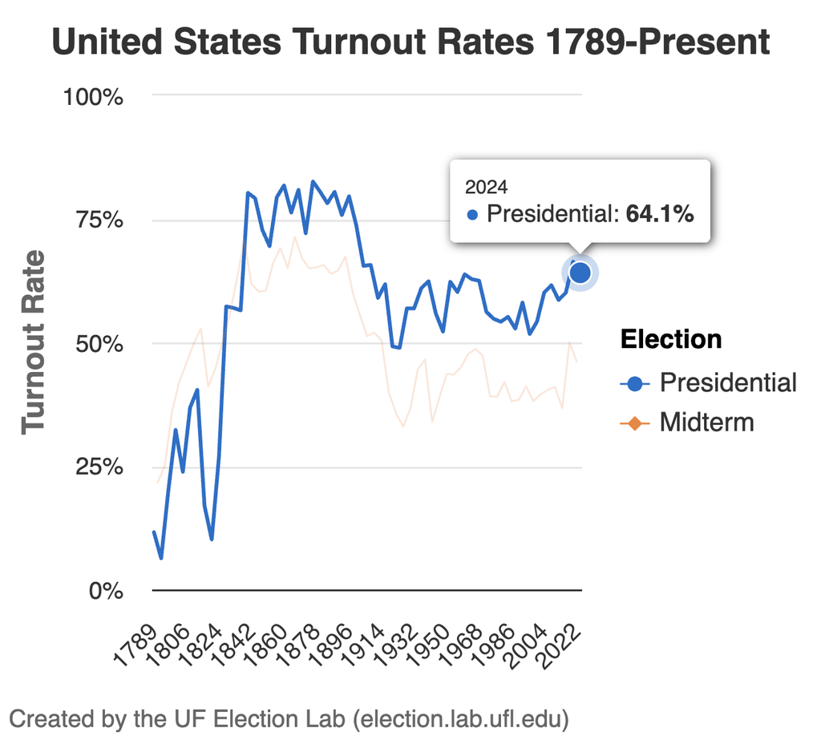

We care as much about *who* votes as we do about *how many*.

### Variation in turnout

- **Descriptive** questions:
  - How does the composition electorate differ from the population (e.g., Citrin, Schickler, and Sides 2003)?
  - How does political voice vary across social groups (e.g., Verba, Schlozman, and Brady 1995)?
- **Causal** questions:
  - Whom do voting reforms (de)mobilize (e.g., Grumbach and Hill 2022)?
  - How does the composition of the electorate affect political representation (e.g., Anzia 2014)?

### Data sources

To answer, we need individual-level microdata:

- **Current Population Survey** (1980ish–2024)
  - November supplement asks whether R voted
- **Cooperative (Congressional) Election Study** (2006–2024)
  - Self-reported and validated turnout
- **Voter file** (2008ish–2024)
  - (Modeled) characteristics of electorate
- **American National Election Study**
  - Occasional validation (e.g., 1988)

### Previous work

- For overall turnout, the most prominent approach is that of Michael McDonald, who relies on aggregate administrative data and the ACS (plus ad-hoc adjustments).
- Previous scholarship on turnout inequality has has relied overwhelmingly on the CPS and secondarily the ANES, especially for over-time comparisons (e.g., Leighley and Nagler 2013; Fraga 2018).
- Political organizations such as Catalyst (“What happened”?) have also released their own reports, often framed in terms of the composition of the electorate rather than turnout.

## Why we need a new approach

### Problems with the CPS

Though often considered the “gold standard” of turnout data, the CPS suffers from several well-known problems:

- Self-reported vote is subject to substantial misreporting
- Although nonresponse is much lower than academic and commercial surveys, the CPS still overrepresents educated Americans relative to the ACS.

### Bias in CPS turnout estimates

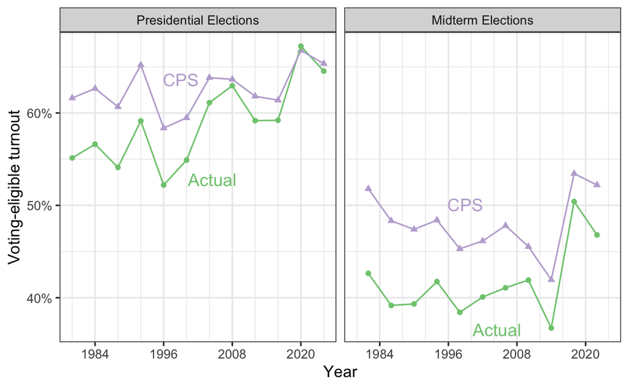

### Problems with other sources

- The CES’s opt-in sample overrepresents the politically engaged—even weighted validated turnout is wildly inflated.
- The ANES is better than the CES, but it hasn’t validated in years and poorly suited for subnational inference.
- The voter file is enormous but doesn’t contain most demographic attributes, which must instead be inferred with proprietary data/models. It also doesn’t contain information about non-voters.
- Ecological inference is most useful for highly segregated groups, but even then it requires assumptions about homogeneity of voting patterns across geographies.

# Methods

### Goals

Estimate turnout…

- with publicly available data
- and transparent methods
- in demographic subgroups
- at the state level
- over time (1980 to 2024)
- while accounting for uncertainty.

### Data

- **State election offices** (adminstrative data)
  - Number of votes cast by geographic unit
- **ACS** (3.5-million-household probability sample)
  - Size and composition of the voting-eligible pop.
- **CPS** (60,000-household probability sample of noninstitutionalized population)
  - Self-reported turnout, plus demographics
- **CES** (50,000-respondent opt-in quota sample)
  - Self-reported and validated vote, plus demographics

### Overview of approach

| Problem | Solution | Data |
| --- | --- | --- |
| Overreporting | Calibration to substate turnout | CPS, ACS, returns |
| Nonresponse | Calibration to substate demographic targets | CPS, ACS |
| *Differential* overreporting | Multiple imputation of validated vote conditional on self-reported vote + demographics | CPS, CES |

We implement these solutions in reverse order.

### Step 1: Multiple imputation

For each election year:

- Concatenate CES and CPS datasets, joining on common variables plus validated vote (entirely missing in CPS).
- Stochastically impute `NA`s 20x using MICE.<sup>1</sup>
  - **Validated vote:** Multilevel model<sup>2</sup> with random effects by state is used for validated vote, with self-reported vote and demographic/geographic attributes as predictors
  - **Other covariates:** predictive mean matching
[^1]: van Buuren and Groothuis-Oudshoorn (2011)
[^2]: To potentially allow for state-level covariates

### Step 2: Demographic calibration

For each imputation:

- Rake the CPS data to match ACS-derived targets for race, education, age, and gender within each state.<sup>1</sup>
- (Some interpolation is necessary to deal with disruptions to the ACS during the COVID pandemic.)
[^3]: Lumley (2010)

### Step 3: Turnout calibration

For each imputation:

- Rake the (demographically calibrated) CPS data to turnout targets at the state/county/MSA level.<sup>1</sup>
- (We do this once for reported vote and once for validated.)
- Two benefits:
  - Ensures that estimates match aggregate benchmarks.
  - Apportions turnout correctly, which matters a lot for segregated groups (e.g., Black Michiganders in Detroit).
[^4]: cf. Hur and Achen (2013)

### Summary of approach

In short:

- Step 3 ensures that CPS turnout estimates match aggregate benchmarks.
- Step 2 ensures that the CPS is demographically representative.
- Step 1 accounts for differential overreporting across states and demographic groups.

We analyze the imputed datasets using Rubin’s rules.<sup>1</sup>

[^5]: Rubin (1987)

# Results

### What do we get out of this?

From the imputated datasets, we can derive bienneial estimates of turnout (or composition of the electorate) for strata defined by CPS demographics and/or substate geography, plus realistic estimates of uncertainty.

- 1980–2024 for reported vote
- 2006–2024 for validated vote

Let’s look at an example.

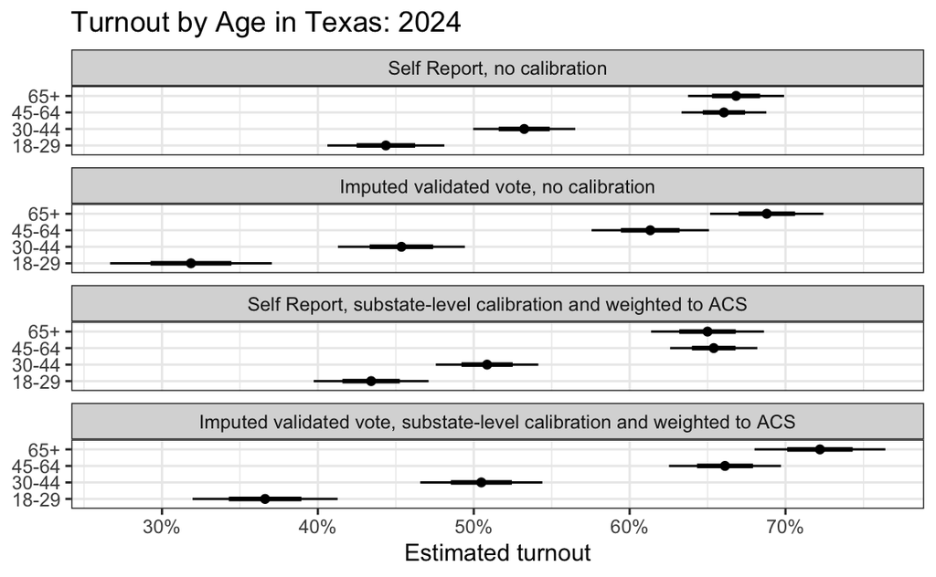

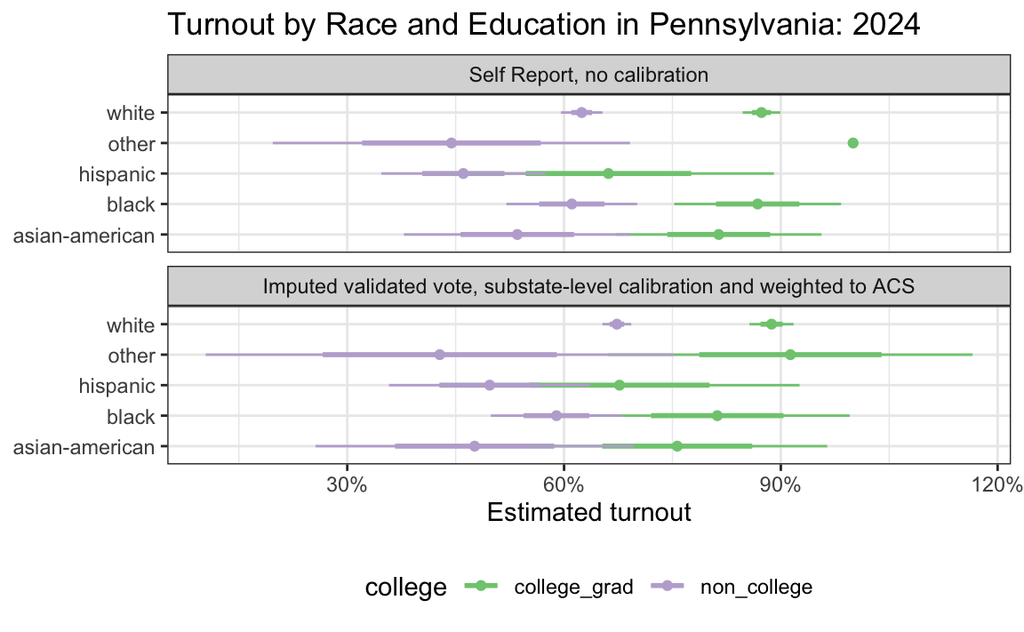

## A substantive application

### The turnout gap

- The scholarly CW is, or at least has been, that “the gap in voting rates between blacks and whites has largely disappeared.”<sup>1</sup>
- Studies that have found otherwise have tended to start in 2008, making it hard to distinguish an Obama effect from long-term trends.
- These studies have relied primarily on CPS self-reports and thus do not account for differential misreporting across race.
[^6]: Leighley and Nagler (2013); see also Fraga (2018)

### Turnout by race: Presidential elections

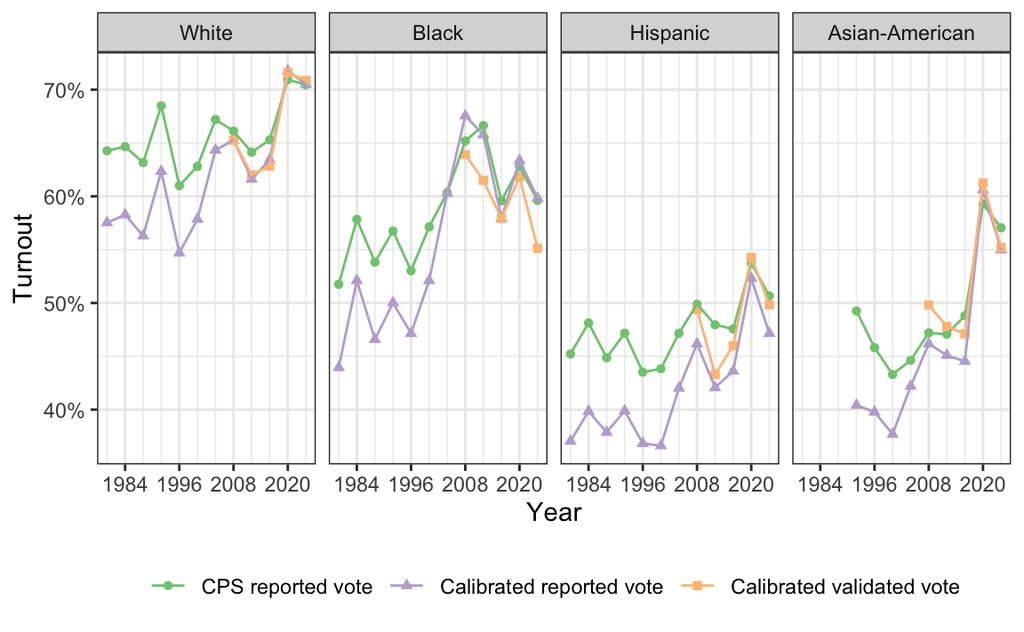

### Turnout by race: Midterm elections

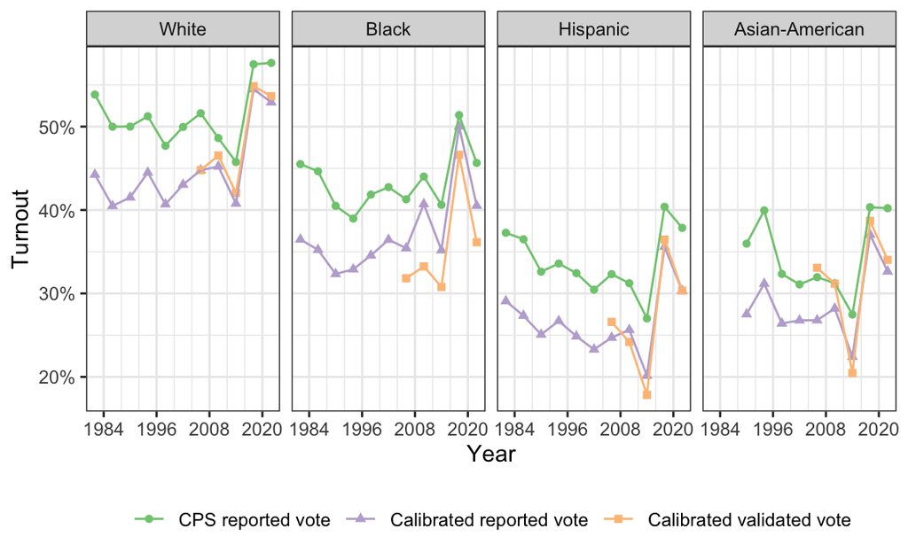

### The turnout gap: Presidential elections

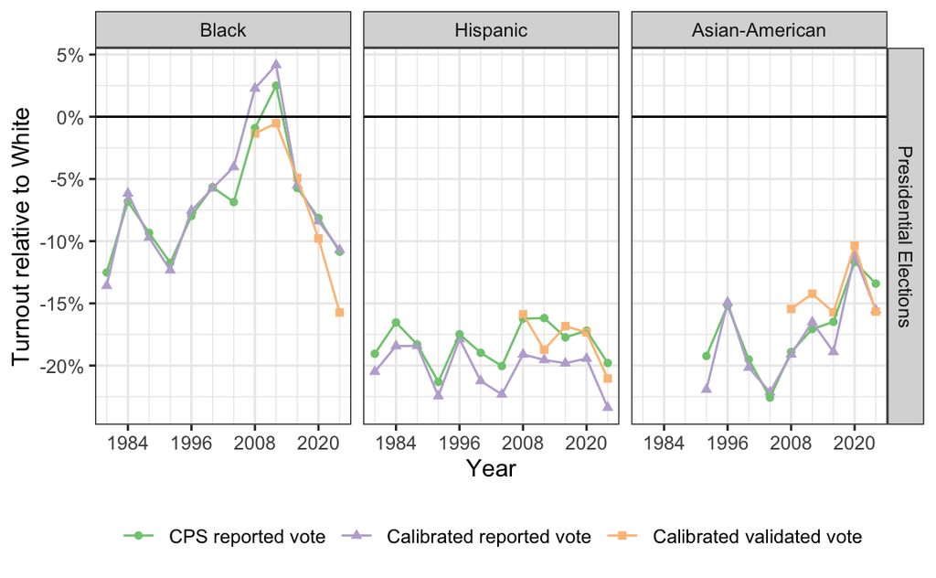

### The turnout gap: Midterm elections

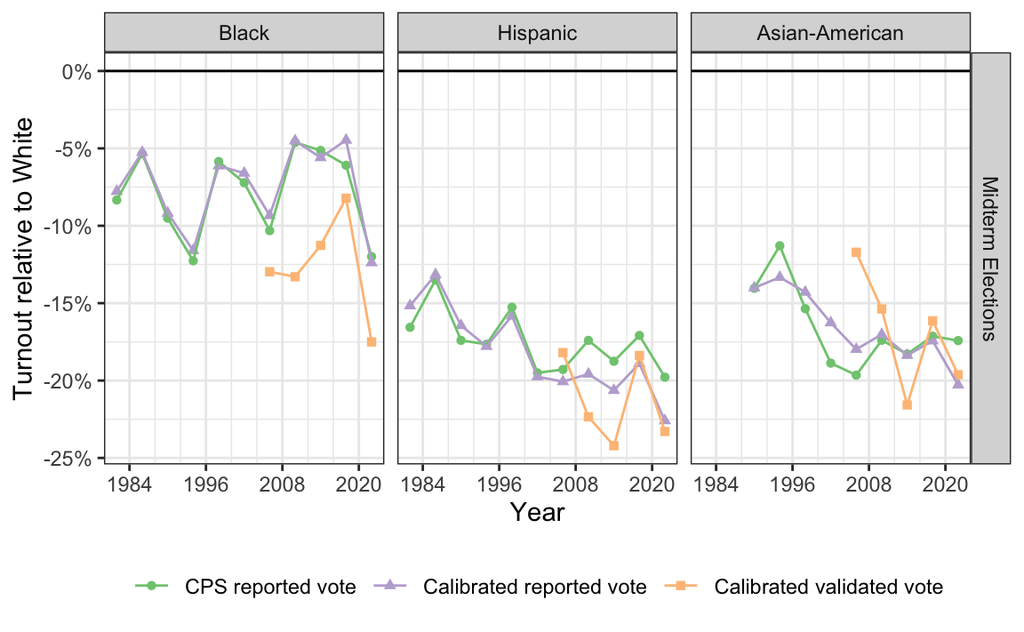

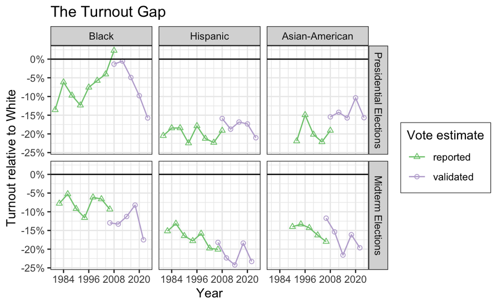

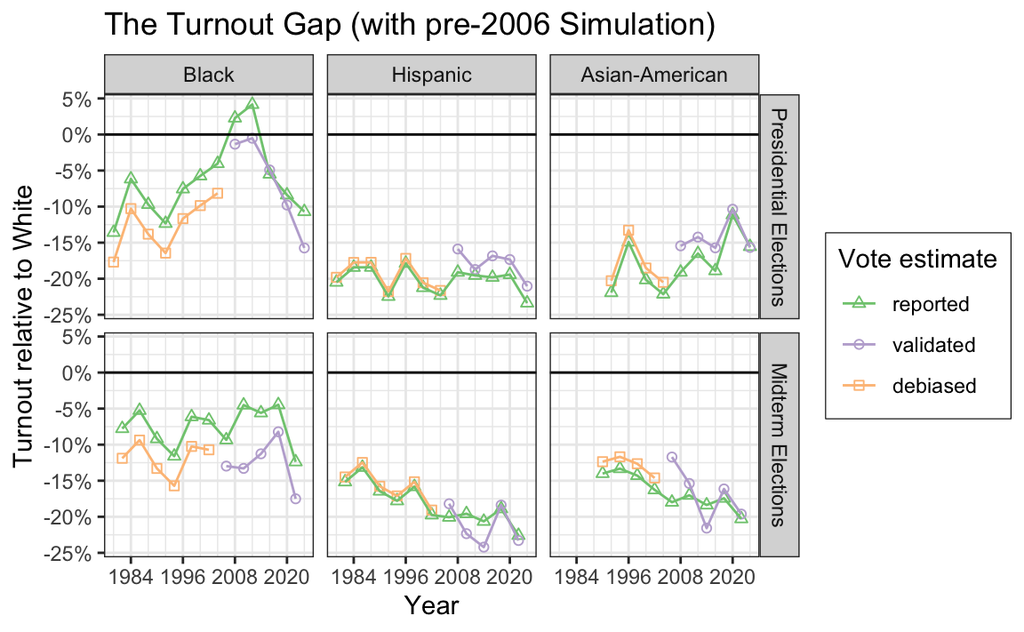

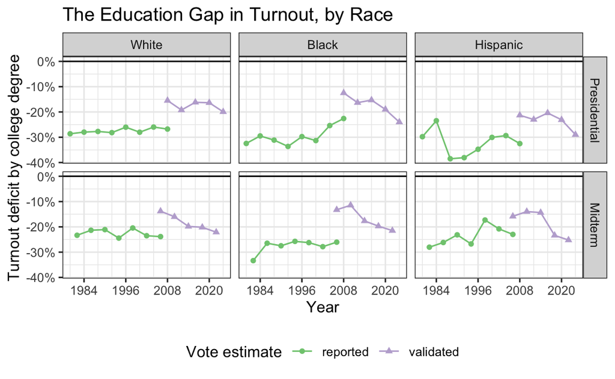

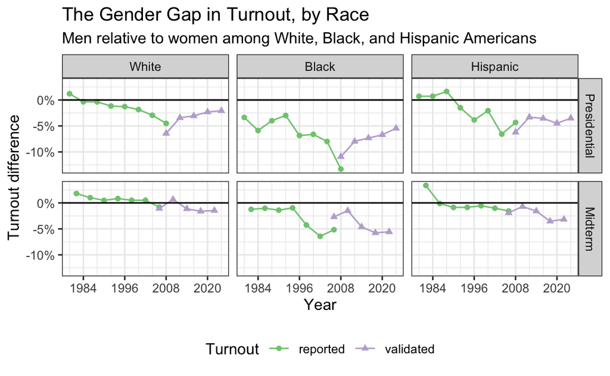

# Next steps

### Explaining the turnout gap’s return

- VRA?
- Decline in mobilization?
- Black disenchantment with the Democratic Party?
- White (counter-)reaction to Trump?

### Other questions

What other questions should we investigate with these measures?

Anzia, Sarah F. 2014. *Timing and Turnout: How Off-Cycle Elections Favor Organized Groups*. Chicago: University of Chicago Press.

Citrin, Jack, Eric Schickler, and John Sides. 2003. “What If Everyone Voted? Simulating the Impact of Increased Turnout in Senate Elections.” *American Journal of Political Science* 47 (1): 75–90.

Fraga, Bernard L. 2018. *The Turnout Gap: Race, Ethnicity, and Political Inequality in a Diversifying America*. New York: Cambridge University Press.

Grumbach, Jacob M., and Charlotte Hill. 2022. “Rock the Registration: Same Day Registration Increases Turnout of Young Voters.” *Journal of Politics* 84 (1): 405–17.

Hur, Aram, and Christopher H. Achen. 2013. “Coding Voter Turnout Responses in the Current Population Survey.” *Public Opinion Quarterly*, no. 4: 985–93.

Leighley, Jan E., and Jonathan Nagler. 2013. *Who Votes Now? Demographics, Issues, Inequality, and Turnout in the United States*. Princeton University Press.

Lumley, Thomas S. 2010. *Complex Surveys: A Guide to Analysis Using R*. Hoboken, NJ: Wiley.

Rubin, Donald B. 1987. *Multiple Imputation for Nonresponse in Surveys*. New York: Wiley.

van Buuren, Stef, and Karin Groothuis-Oudshoorn. 2011. “mice: Multivariate Imputation by Chained Equations in R.” *Journal of Statistical Software* 45 (3): 1–67. https://doi.org/10.18637/jss.v045.i03.

Verba, Sidney, Kay Lehman Schlozman, and Henry E. Brady. 1995. *Voice and Equality: Civic Voluntarism in American Politics*. Cambridge, MA: Harvard University Press.